# Análisis evolución Covid-19 Chile casos y decesos (11/04/2020)

Claudio Bustos

11/4/2020

- Reportes anteriores: https://github.com/clbustos/analisis_covid19_chile

**Comentario técnico**: Como ha habido críticas sobre la capacidad de diferencias colores, me preocupé de establecer contrastes más fuertes entre las líneas, así como una cierta lógica de colores de acuerdo a la zona geográfica. Aparte, del Open Salud LAB aprendí a poner etiquetas ‘inteligentes’ en cada serie (gracias, Paulo).

## Análisis de series de casos

La serie de casos se hace hace partir de los 20 casos, excepto para Atacama y Aysén, donde se inicia del quinto caso, para facilitar la comparación desde un punto de un punto de partida común, ya que la aparición de los primeros casos siempre es un tanto errática. La serie de datos total tiene un patrón en 4 fases, las dos primeras de ascenso prácticamente exponencial (días 0 a 10, y 10 a 14), una también exponencial con menor tasa (14-20) y la actual, que parece haberse estancado en una tasa menor a los periodos anteriores en la última semana.

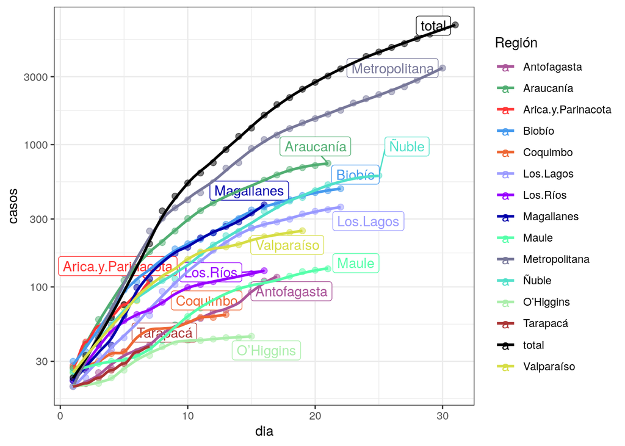

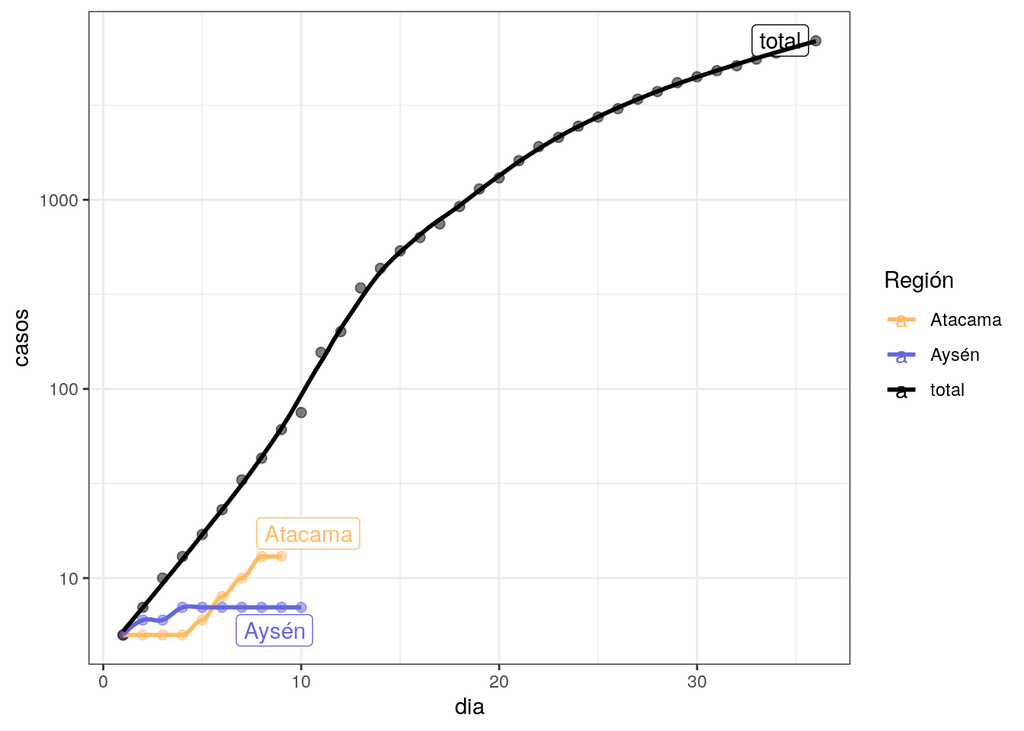

La serie por región se hace partir de los 5 primeros casos.

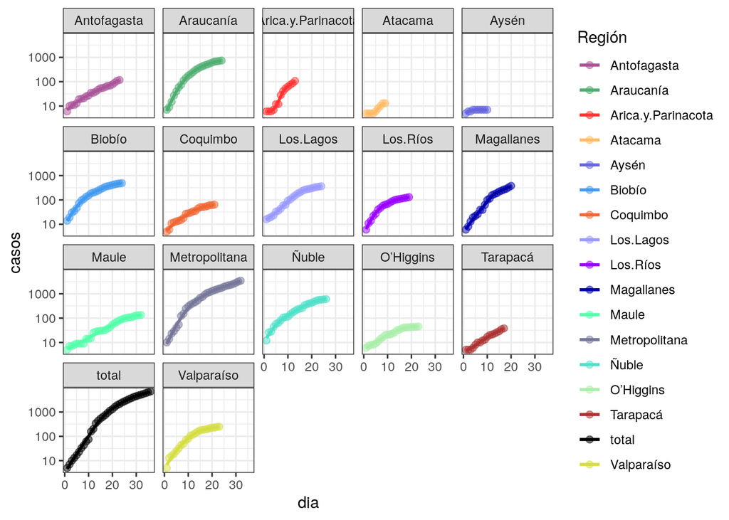

Si observamos la proporción de casos nuevos por región, observamos tendencias ascendentes en Antofagasta, Metropolitana y Magallanes. La leve tendencia al alza de varias regiones parece haberse detenido un poco, pero es necesario esperar algunos días para ver cuales serán los efectos de este fin de semana largo.

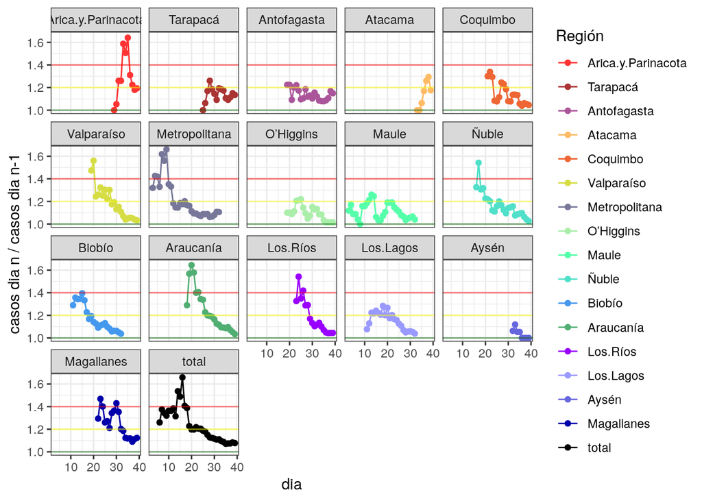

En el gráfico FSDG, se observa la inestabilidad de tasa de Arica y Parinacota, así como la estabilización del resto de la serie.

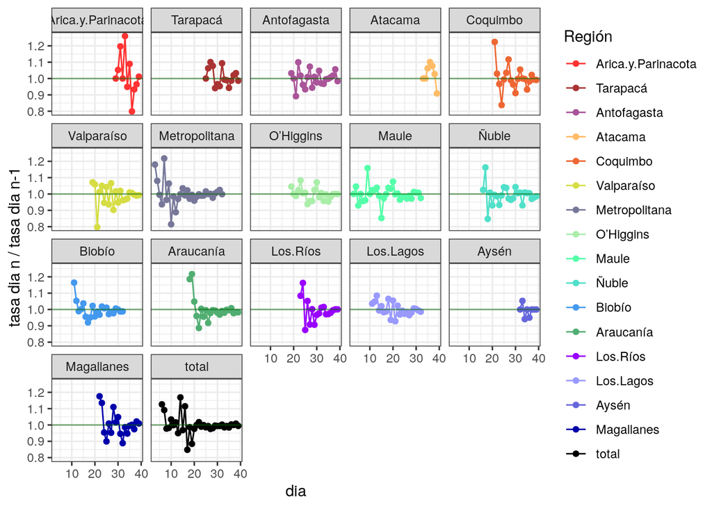

## Predicción

### Predicción para serie total

Recordemos que la regresión exponencial se eliminó, porque ya no calza con la serie total. A partir del análisis del resultado del algoritmo de la última semana, para la predicción total se recorta la serie a partir de lo 50 casos.

Primero, veamos como ha estado el desempeño de los algoritmos durante el presente periodo. Hace 3 días, se predijo para hoy 6387 y 6443 casos con AR(1) y AR(4), respectivamente, lo cual queda bastante corto con los datos reales. ARIMA, como siempre, da un valor más alto, pero en todos los casos se cumple el intervalo de confianza.

|  | casos | li | ls |
| --- | --- | --- | --- |
| **Observado** | 6927 | NA | NA |
| **ARIMA(1,1,0)** | 9241.374 | 4952.037 | 17246.03 |
| **T+AR(1)** | 6387.842 | 5983.619 | 7173.179 |
| **T+AR(4)** | 6443.397 | 6063.48 | 7106.934 |

Al igual que ayer, AR(1) es más pesimista que AR(4).

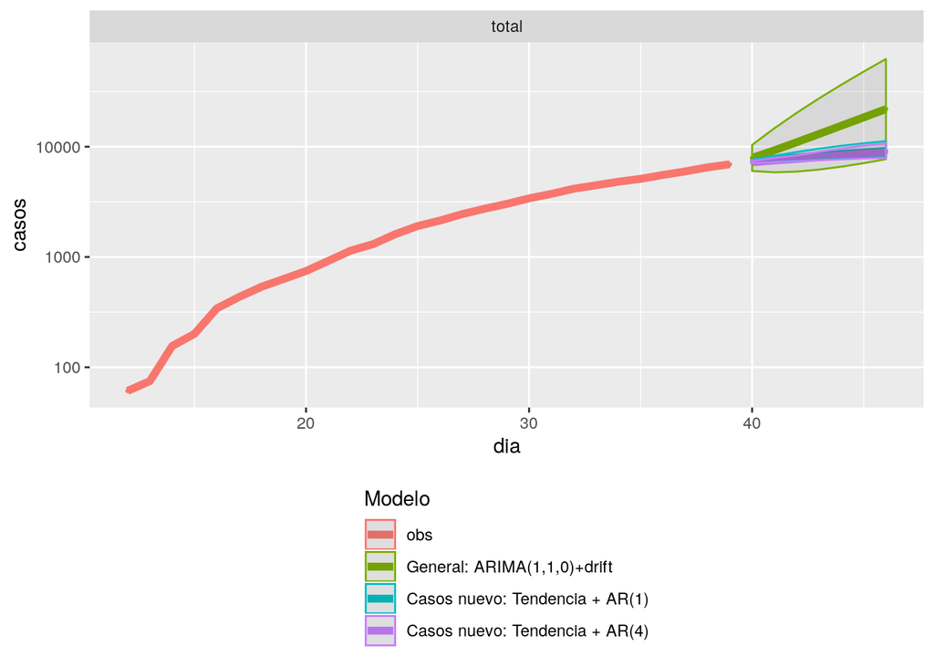

Casos nuevos: tendencia + AR(4) : total

|  | dia | casos | li | ls |
| --- | --- | --- | --- | --- |
| **29** | 40 | 7229 | 7109 | 7427 |
| **30** | 41 | 7503 | 7266 | 7904 |
| **31** | 42 | 7748 | 7402 | 8348 |
| **32** | 43 | 8055 | 7548 | 8990 |
| **33** | 44 | 8349 | 7687 | 9614 |
| **34** | 45 | 8643 | 7824 | 10246 |
| **35** | 46 | 8864 | 7923 | 10742 |

Casos nuevos: tendencia + AR(1) : total

|  | dia | casos | li | ls |
| --- | --- | --- | --- | --- |
| **29** | 40 | 7281 | 7121 | 7572 |
| **30** | 41 | 7646 | 7307 | 8290 |
| **31** | 42 | 7980 | 7474 | 8958 |
| **32** | 43 | 8300 | 7633 | 9601 |
| **33** | 44 | 8595 | 7779 | 10196 |
| **34** | 45 | 8869 | 7916 | 10748 |
| **35** | 46 | 9119 | 8040 | 11252 |

ARIMA(1,1,0) con deriva : total

|  | dia | casos | li | ls |
| --- | --- | --- | --- | --- |
| **29** | 40 | 7919 | 6031 | 10397 |
| **30** | 41 | 9286 | 5862 | 14710 |
| **31** | 42 | 10989 | 5948 | 20303 |
| **32** | 43 | 13049 | 6205 | 27441 |
| **33** | 44 | 15513 | 6592 | 36503 |
| **34** | 45 | 18450 | 7094 | 47981 |
| **35** | 46 | 21947 | 7707 | 62495 |

### Predicciones para serie total usando predicción por regiones.

Otro modelo posible de análisis es usar la suma de las predicciones parciales por región. No he calculado los intervalos de confianza, porque para que sean adecuados debería considerar la covarianza entre las series de las distintas regiones.

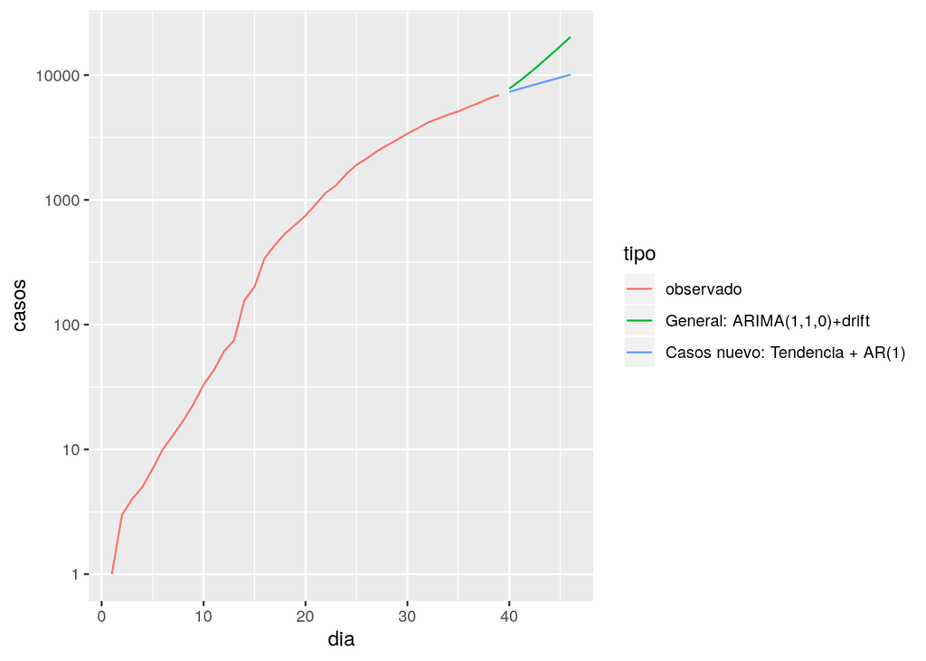

| dia | tipo | casos |
| --- | --- | --- |
| 1 | observado | 1 |
| 2 | observado | 3 |
| 3 | observado | 4 |
| 4 | observado | 5 |
| 5 | observado | 7 |
| 6 | observado | 10 |
| 7 | observado | 13 |
| 8 | observado | 17 |
| 9 | observado | 23 |
| 10 | observado | 33 |
| 11 | observado | 43 |
| 12 | observado | 61 |
| 13 | observado | 75 |
| 14 | observado | 156 |
| 15 | observado | 201 |
| 16 | observado | 342 |
| 17 | observado | 434 |
| 18 | observado | 537 |
| 19 | observado | 632 |
| 20 | observado | 746 |
| 21 | observado | 922 |
| 22 | observado | 1142 |
| 23 | observado | 1306 |
| 24 | observado | 1610 |
| 25 | observado | 1909 |
| 26 | observado | 2139 |
| 27 | observado | 2449 |
| 28 | observado | 2738 |
| 29 | observado | 3031 |
| 30 | observado | 3404 |
| 31 | observado | 3737 |
| 32 | observado | 4161 |
| 33 | observado | 4471 |
| 34 | observado | 4815 |
| 35 | observado | 5116 |
| 36 | observado | 5546 |
| 37 | observado | 5972 |
| 38 | observado | 6501 |
| 39 | observado | 6927 |
| 40 | General: ARIMA(1,1,0)+drift | 7794 |
| 41 | General: ARIMA(1,1,0)+drift | 8951 |
| 42 | General: ARIMA(1,1,0)+drift | 10412 |
| 43 | General: ARIMA(1,1,0)+drift | 12207 |
| 44 | General: ARIMA(1,1,0)+drift | 14389 |
| 45 | General: ARIMA(1,1,0)+drift | 17029 |
| 46 | General: ARIMA(1,1,0)+drift | 20214 |
| 40 | Casos nuevo: Tendencia + AR(1) | 7327 |
| 41 | Casos nuevo: Tendencia + AR(1) | 7745 |
| 42 | Casos nuevo: Tendencia + AR(1) | 8171 |
| 43 | Casos nuevo: Tendencia + AR(1) | 8615 |
| 44 | Casos nuevo: Tendencia + AR(1) | 9079 |
| 45 | Casos nuevo: Tendencia + AR(1) | 9569 |
| 46 | Casos nuevo: Tendencia + AR(1) | 10090 |

### Predicción por regiones

Hemos modificado el algoritmo para iniciar desde 3 casos en cada Región . En Atacama ya no tenemos el exceso de pesimismo de AR(1) del día de ayer.

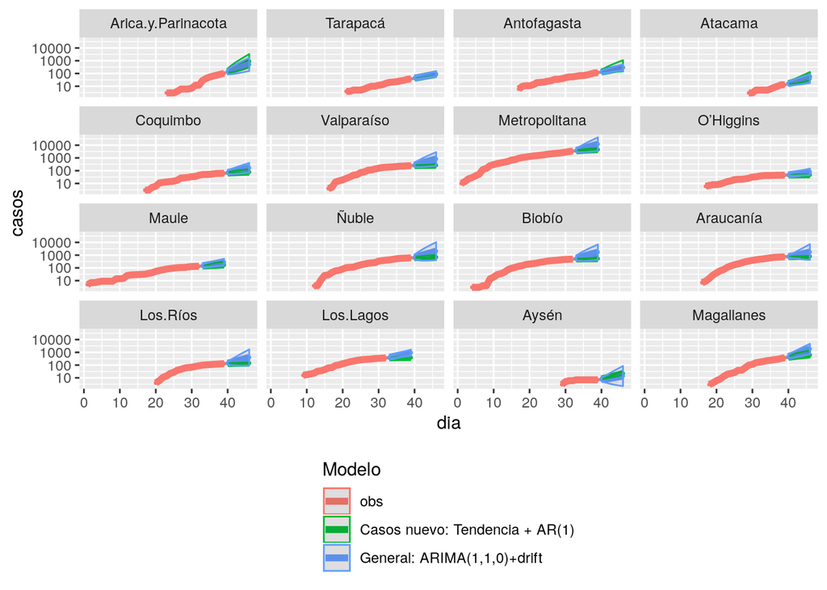

Las tablas por regiones se incluye en el Anexo I

## Decesos

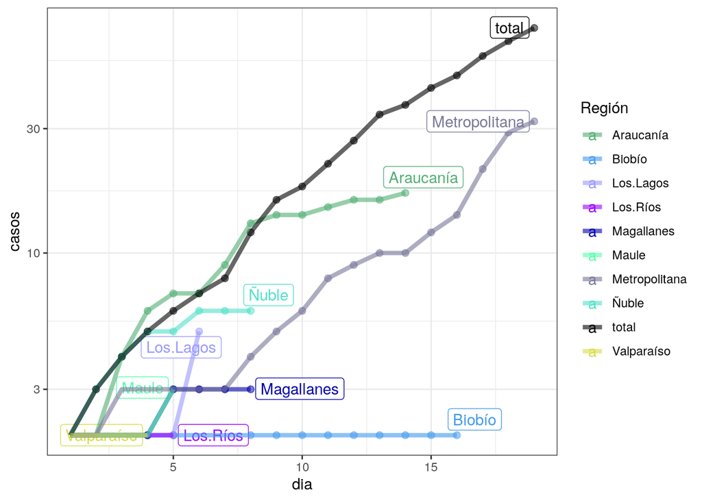

**Fuentes de información**: Principalmente, se utilizó el reporte diario del [MINSAL](https://www.minsal.cl/nuevo-coronavirus-2019-ncov/casos-confirmados-en-chile-covid-19/), usando [Wayback machine](https://archive.org/web/) para recopilar la información ya no disponible.

## Anexo I: Predicciones por región

Casos nuevos: tendencia + AR(1) : Arica.y.Parinacota

|  | dia | casos | li | ls |
| --- | --- | --- | --- | --- |
| **18** | 40 | 140.5 | 115.3 | 241 |
| **19** | 41 | 185.5 | 126.5 | 423.1 |
| **20** | 42 | 248.3 | 142 | 677.2 |
| **21** | 43 | 336.7 | 163.9 | 1034 |
| **22** | 44 | 462.1 | 194.9 | 1542 |
| **23** | 45 | 642 | 239.4 | 2269 |
| **24** | 46 | 902.7 | 303.9 | 3323 |

Casos nuevos: tendencia + AR(1) : Tarapacá

|  | dia | casos | li | ls |
| --- | --- | --- | --- | --- |
| **20** | 40 | 42.75 | 40.06 | 48.91 |
| **21** | 41 | 47.69 | 42.16 | 60.56 |
| **22** | 42 | 53.42 | 44.59 | 74.08 |
| **23** | 43 | 59.92 | 47.35 | 89.43 |
| **24** | 44 | 67.38 | 50.51 | 107 |
| **25** | 45 | 75.96 | 54.14 | 127.3 |
| **26** | 46 | 85.87 | 58.34 | 150.7 |

Casos nuevos: tendencia + AR(1) : Antofagasta

|  | dia | casos | li | ls |
| --- | --- | --- | --- | --- |
| **24** | 40 | 131.4 | 119.7 | 193.8 |
| **25** | 41 | 146.3 | 122.3 | 278.2 |
| **26** | 42 | 165.1 | 125.7 | 383.9 |
| **27** | 43 | 187.6 | 129.6 | 511.3 |
| **28** | 44 | 215.2 | 134.5 | 667.7 |
| **29** | 45 | 249.4 | 140.6 | 860.6 |
| **30** | 46 | 291.8 | 148.1 | 1101 |

Casos nuevos: tendencia + AR(1) : Atacama

|  | dia | casos | li | ls |
| --- | --- | --- | --- | --- |
| **12** | 40 | 16.34 | 14.33 | 21.43 |
| **13** | 41 | 19.21 | 15.4 | 29.08 |
| **14** | 42 | 23.32 | 16.93 | 40.08 |
| **15** | 43 | 28.39 | 18.82 | 53.68 |
| **16** | 44 | 35.2 | 21.36 | 71.97 |
| **17** | 45 | 44.39 | 24.78 | 96.63 |
| **18** | 46 | 57.18 | 29.55 | 131 |

Casos nuevos: tendencia + AR(1) : Coquimbo

|  | dia | casos | li | ls |
| --- | --- | --- | --- | --- |
| **24** | 40 | 66.11 | 64.42 | 74.66 |
| **25** | 41 | 68.25 | 64.83 | 85.75 |
| **26** | 42 | 70.26 | 65.22 | 96.21 |
| **27** | 43 | 72.17 | 65.59 | 106.1 |
| **28** | 44 | 73.96 | 65.93 | 115.4 |
| **29** | 45 | 75.63 | 66.25 | 124.1 |
| **30** | 46 | 77.19 | 66.55 | 132.2 |

Casos nuevos: tendencia + AR(1) : Valparaíso

|  | dia | casos | li | ls |
| --- | --- | --- | --- | --- |
| **25** | 40 | 252.3 | 249.5 | 259.9 |
| **26** | 41 | 256.1 | 250.8 | 271.5 |
| **27** | 42 | 258.9 | 251.7 | 280.1 |
| **28** | 43 | 261.1 | 252.4 | 286.8 |
| **29** | 44 | 262.7 | 253 | 291.8 |
| **30** | 45 | 263.9 | 253.3 | 295.4 |
| **31** | 46 | 264.7 | 253.6 | 297.9 |

Casos nuevos: tendencia + AR(1) : Metropolitana

|  | dia | casos | li | ls |
| --- | --- | --- | --- | --- |
| **33** | 33 | 3635 | 3521 | 3928 |
| **34** | 34 | 3803 | 3585 | 4367 |
| **35** | 35 | 3959 | 3644 | 4775 |
| **36** | 36 | 4103 | 3699 | 5153 |
| **37** | 37 | 4235 | 3750 | 5501 |
| **38** | 38 | 4356 | 3796 | 5819 |
| **39** | 39 | 4466 | 3838 | 6106 |

Casos nuevos: tendencia + AR(1) : O’Higgins

|  | dia | casos | li | ls |
| --- | --- | --- | --- | --- |
| **24** | 40 | 45.61 | 45.21 | 46.79 |
| **25** | 41 | 46.09 | 45.37 | 48.23 |
| **26** | 42 | 46.47 | 45.5 | 49.35 |
| **27** | 43 | 46.76 | 45.6 | 50.2 |
| **28** | 44 | 46.97 | 45.67 | 50.83 |
| **29** | 45 | 47.13 | 45.72 | 51.29 |
| **30** | 46 | 47.24 | 45.76 | 51.63 |

Casos nuevos: tendencia + AR(1) : Maule

|  | dia | casos | li | ls |
| --- | --- | --- | --- | --- |
| **33** | 33 | 138.7 | 135 | 156.3 |
| **34** | 34 | 143.8 | 136 | 181.9 |
| **35** | 35 | 149 | 137 | 208.1 |
| **36** | 36 | 154.2 | 138.1 | 234 |
| **37** | 37 | 159.2 | 139.1 | 259.5 |
| **38** | 38 | 164.2 | 140.1 | 284.5 |
| **39** | 39 | 169.1 | 141 | 308.9 |

Casos nuevos: tendencia + AR(1) : Ñuble

|  | dia | casos | li | ls |
| --- | --- | --- | --- | --- |
| **29** | 40 | 624.9 | 610.2 | 690.5 |
| **30** | 41 | 641.4 | 613.9 | 765 |
| **31** | 42 | 656 | 617.1 | 831.2 |
| **32** | 43 | 668.7 | 619.9 | 888.9 |
| **33** | 44 | 679.7 | 622.3 | 938.6 |
| **34** | 45 | 689.1 | 624.4 | 981 |
| **35** | 46 | 697 | 626.1 | 1017 |

Casos nuevos: tendencia + AR(1) : Biobío

|  | dia | casos | li | ls |
| --- | --- | --- | --- | --- |
| **30** | 33 | 500.6 | 494.1 | 517.2 |
| **31** | 34 | 509.2 | 497.4 | 539.2 |
| **32** | 35 | 515.9 | 500.1 | 556.4 |
| **33** | 36 | 521 | 502.1 | 569.6 |
| **34** | 37 | 524.8 | 503.6 | 579.5 |
| **35** | 38 | 527.7 | 504.6 | 586.8 |
| **36** | 39 | 529.7 | 505.4 | 592 |

Casos nuevos: tendencia + AR(1) : Araucanía

|  | dia | casos | li | ls |
| --- | --- | --- | --- | --- |
| **25** | 40 | 755.3 | 747.6 | 769.8 |
| **26** | 41 | 767.9 | 754.3 | 793.5 |
| **27** | 42 | 777.3 | 759.3 | 811.3 |
| **28** | 43 | 784.2 | 762.9 | 824.3 |
| **29** | 44 | 789.1 | 765.5 | 833.5 |
| **30** | 45 | 792.4 | 767.3 | 839.8 |
| **31** | 46 | 794.7 | 768.5 | 844.1 |

Casos nuevos: tendencia + AR(1) : Los.Ríos

|  | dia | casos | li | ls |
| --- | --- | --- | --- | --- |
| **21** | 40 | 133.2 | 131.4 | 137.1 |
| **22** | 41 | 135.9 | 132.6 | 143.4 |
| **23** | 42 | 138.1 | 133.6 | 148.5 |
| **24** | 43 | 139.9 | 134.3 | 152.4 |
| **25** | 44 | 141.2 | 134.9 | 155.5 |
| **26** | 45 | 142.2 | 135.4 | 157.8 |
| **27** | 46 | 143 | 135.7 | 159.5 |

Casos nuevos: tendencia + AR(1) : Los.Lagos

|  | dia | casos | li | ls |
| --- | --- | --- | --- | --- |
| **25** | 33 | 370.4 | 366.5 | 380.1 |
| **26** | 34 | 377 | 368.9 | 398.6 |
| **27** | 35 | 381.4 | 370.5 | 411.1 |
| **28** | 36 | 384.9 | 371.7 | 421 |
| **29** | 37 | 387.3 | 372.5 | 427.9 |
| **30** | 38 | 389.1 | 373.1 | 432.9 |
| **31** | 39 | 390.2 | 373.6 | 436.2 |

Casos nuevos: tendencia + AR(1) : Aysén

|  | dia | casos | li | ls |
| --- | --- | --- | --- | --- |
| **12** | 40 | 8.25 | 7.9 | 8.74 |
| **13** | 41 | 9.59 | 8.83 | 10.66 |
| **14** | 42 | 11.18 | 9.93 | 12.97 |
| **15** | 43 | 13.07 | 11.23 | 15.71 |
| **16** | 44 | 15.38 | 12.83 | 19.07 |
| **17** | 45 | 18.29 | 14.83 | 23.29 |
| **18** | 46 | 22.04 | 17.42 | 28.73 |

Casos nuevos: tendencia + AR(1) : Magallanes

|  | dia | casos | li | ls |
| --- | --- | --- | --- | --- |
| **23** | 40 | 410.2 | 385.3 | 510.2 |
| **24** | 41 | 446.9 | 394 | 664.8 |
| **25** | 42 | 482.5 | 402.4 | 815.3 |
| **26** | 43 | 517.6 | 410.7 | 964 |
| **27** | 44 | 551.6 | 418.8 | 1108 |
| **28** | 45 | 584.1 | 426.4 | 1245 |
| **29** | 46 | 614.6 | 433.7 | 1374 |

ARIMA(1,1,0) con deriva : Arica.y.Parinacota

|  | dia | casos | li | ls |
| --- | --- | --- | --- | --- |
| **18** | 40 | 134 | 83.56 | 215 |
| **19** | 41 | 167.7 | 87.73 | 320.7 |
| **20** | 42 | 209.9 | 95.61 | 460.8 |
| **21** | 43 | 262.7 | 106.4 | 648.4 |
| **22** | 44 | 328.7 | 120 | 900.1 |
| **23** | 45 | 411.3 | 136.8 | 1237 |
| **24** | 46 | 514.8 | 156.9 | 1688 |

ARIMA(1,1,0) con deriva : Tarapacá

|  | dia | casos | li | ls |
| --- | --- | --- | --- | --- |
| **20** | 40 | 43.35 | 35.87 | 52.39 |
| **21** | 41 | 49.14 | 38.21 | 63.2 |
| **22** | 42 | 55.75 | 41.18 | 75.47 |
| **23** | 43 | 63.24 | 44.72 | 89.43 |
| **24** | 44 | 71.74 | 48.81 | 105.5 |
| **25** | 45 | 81.39 | 53.46 | 123.9 |
| **26** | 46 | 92.33 | 58.71 | 145.2 |

ARIMA(1,1,0) con deriva : Antofagasta

|  | dia | casos | li | ls |
| --- | --- | --- | --- | --- |
| **24** | 40 | 135.6 | 106.3 | 173.1 |
| **25** | 41 | 154.3 | 113.2 | 210.5 |
| **26** | 42 | 176.3 | 121.8 | 255.4 |
| **27** | 43 | 201.3 | 132.1 | 306.8 |
| **28** | 44 | 229.9 | 144.2 | 366.5 |
| **29** | 45 | 262.4 | 157.9 | 436.1 |
| **30** | 46 | 299.6 | 173.5 | 517.4 |

ARIMA(1,1,0) con deriva : Atacama

|  | dia | casos | li | ls |
| --- | --- | --- | --- | --- |
| **12** | 40 | 15.7 | 11 | 22.43 |
| **13** | 41 | 18.13 | 11.59 | 28.37 |
| **14** | 42 | 21.16 | 12.41 | 36.11 |
| **15** | 43 | 24.64 | 13.44 | 45.17 |
| **16** | 44 | 28.7 | 14.67 | 56.15 |
| **17** | 45 | 33.43 | 16.11 | 69.37 |
| **18** | 46 | 38.94 | 17.77 | 85.33 |

ARIMA(1,1,0) con deriva : Coquimbo

|  | dia | casos | li | ls |
| --- | --- | --- | --- | --- |
| **24** | 40 | 73.57 | 52.92 | 102.3 |
| **25** | 41 | 84.55 | 53.09 | 134.7 |
| **26** | 42 | 97.17 | 54.97 | 171.8 |
| **27** | 43 | 111.7 | 57.86 | 215.6 |
| **28** | 44 | 128.3 | 61.53 | 267.7 |
| **29** | 45 | 147.5 | 65.93 | 330 |
| **30** | 46 | 169.5 | 71.04 | 404.5 |

ARIMA(1,1,0) con deriva : Valparaíso

|  | dia | casos | li | ls |
| --- | --- | --- | --- | --- |
| **25** | 40 | 288.7 | 195.1 | 427.3 |
| **26** | 41 | 343.5 | 187.6 | 629.1 |
| **27** | 42 | 410.3 | 190.3 | 884.6 |
| **28** | 43 | 490.4 | 198.7 | 1210 |
| **29** | 44 | 586.2 | 211.2 | 1627 |
| **30** | 45 | 700.7 | 227.2 | 2161 |
| **31** | 46 | 837.6 | 246.6 | 2845 |

ARIMA(1,1,0) con deriva : Metropolitana

|  | dia | casos | li | ls |
| --- | --- | --- | --- | --- |
| **33** | 33 | 3986 | 2941 | 5402 |
| **34** | 34 | 4733 | 2810 | 7973 |
| **35** | 35 | 5680 | 2814 | 11467 |
| **36** | 36 | 6845 | 2908 | 16111 |
| **37** | 37 | 8262 | 3071 | 22225 |
| **38** | 38 | 9979 | 3294 | 30230 |
| **39** | 39 | 12055 | 3573 | 40676 |

ARIMA(1,1,0) con deriva : O’Higgins

|  | dia | casos | li | ls |
| --- | --- | --- | --- | --- |
| **24** | 40 | 48.06 | 41.41 | 55.77 |
| **25** | 41 | 52.16 | 40.5 | 67.16 |
| **26** | 42 | 56.94 | 40.59 | 79.88 |
| **27** | 43 | 62.31 | 41.32 | 93.97 |
| **28** | 44 | 68.24 | 42.5 | 109.6 |
| **29** | 45 | 74.76 | 44.03 | 126.9 |
| **30** | 46 | 81.91 | 45.86 | 146.3 |

ARIMA(1,1,0) con deriva : Maule

|  | dia | casos | li | ls |
| --- | --- | --- | --- | --- |
| **33** | 33 | 150.2 | 117.2 | 192.4 |
| **34** | 34 | 166.8 | 119.4 | 232.8 |
| **35** | 35 | 185.3 | 123.9 | 277.4 |
| **36** | 36 | 206 | 129.8 | 327 |
| **37** | 37 | 229 | 136.9 | 382.9 |
| **38** | 38 | 254.5 | 145.1 | 446.2 |
| **39** | 39 | 282.8 | 154.4 | 518 |

ARIMA(1,1,0) con deriva : Ñuble

|  | dia | casos | li | ls |
| --- | --- | --- | --- | --- |
| **29** | 40 | 697.5 | 436.1 | 1116 |
| **30** | 41 | 827.2 | 387.7 | 1765 |
| **31** | 42 | 989 | 369.5 | 2647 |
| **32** | 43 | 1185 | 366.8 | 3827 |
| **33** | 44 | 1420 | 373.5 | 5400 |
| **34** | 45 | 1703 | 387.1 | 7488 |
| **35** | 46 | 2041 | 406.6 | 10250 |

ARIMA(1,1,0) con deriva : Biobío

|  | dia | casos | li | ls |
| --- | --- | --- | --- | --- |
| **30** | 33 | 580 | 356.5 | 943.6 |
| **31** | 34 | 694.4 | 338.9 | 1423 |
| **32** | 35 | 832 | 340.9 | 2030 |
| **33** | 36 | 997 | 353.1 | 2815 |
| **34** | 37 | 1195 | 372.4 | 3833 |
| **35** | 38 | 1432 | 397.7 | 5154 |
| **36** | 39 | 1716 | 428.9 | 6864 |

ARIMA(1,1,0) con deriva : Araucanía

|  | dia | casos | li | ls |
| --- | --- | --- | --- | --- |
| **25** | 40 | 792.2 | 655.4 | 957.6 |
| **26** | 41 | 871.1 | 591 | 1284 |
| **27** | 42 | 977.3 | 537.1 | 1778 |
| **28** | 43 | 1114 | 494.7 | 2507 |
| **29** | 44 | 1285 | 462.7 | 3568 |
| **30** | 45 | 1497 | 439.5 | 5098 |
| **31** | 46 | 1757 | 423.8 | 7287 |

ARIMA(1,1,0) con deriva : Los.Ríos

|  | dia | casos | li | ls |
| --- | --- | --- | --- | --- |
| **21** | 40 | 144.6 | 109.9 | 190.2 |
| **22** | 41 | 166.4 | 99.58 | 278.1 |
| **23** | 42 | 195.4 | 93.6 | 408 |
| **24** | 43 | 232.2 | 90.86 | 593.4 |
| **25** | 44 | 277.8 | 90.54 | 852.1 |
| **26** | 45 | 333.6 | 92.13 | 1208 |
| **27** | 46 | 401.6 | 95.31 | 1692 |

ARIMA(1,1,0) con deriva : Los.Lagos

|  | dia | casos | li | ls |
| --- | --- | --- | --- | --- |
| **25** | 33 | 416.2 | 339.6 | 510.2 |
| **26** | 34 | 476.7 | 356.5 | 637.4 |
| **27** | 35 | 546 | 382.1 | 780.3 |
| **28** | 36 | 625.4 | 413.9 | 945.1 |
| **29** | 37 | 716.4 | 451.3 | 1137 |
| **30** | 38 | 820.5 | 494.5 | 1362 |
| **31** | 39 | 939.8 | 543.7 | 1625 |

ARIMA(1,1,0) con deriva : Aysén

|  | dia | casos | li | ls |
| --- | --- | --- | --- | --- |
| **12** | 40 | 7.32 | 5.41 | 9.91 |
| **13** | 41 | 7.89 | 4.38 | 14.21 |
| **14** | 42 | 8.67 | 3.64 | 20.63 |
| **15** | 43 | 9.65 | 3.11 | 29.9 |
| **16** | 44 | 10.83 | 2.74 | 42.9 |
| **17** | 45 | 12.23 | 2.46 | 60.81 |
| **18** | 46 | 13.87 | 2.26 | 85.09 |

ARIMA(1,1,0) con deriva : Magallanes

|  | dia | casos | li | ls |
| --- | --- | --- | --- | --- |
| **23** | 40 | 467.1 | 344.9 | 632.5 |
| **24** | 41 | 586.4 | 369 | 931.9 |
| **25** | 42 | 737.6 | 410.8 | 1324 |
| **26** | 43 | 928.1 | 467.2 | 1844 |
| **27** | 44 | 1168 | 538.3 | 2534 |
| **28** | 45 | 1470 | 625.8 | 3451 |
| **29** | 46 | 1849 | 732.5 | 4669 |